# Hanley_AI_Fellowship_Screener

### Academic Innovation Data Science Fellowship Screener

```python
import pandas as pd
import matplotlib.pyplot as plt
import seaborn as sns
%matplotlib inline
```

[figure not shown]

First, we want to read the data into a Pandas dataframe and check its dimensions in order to gain a clearer idea of what we're working with. The dataset isn't too big, with only 173 observations (rows) and 11 variables (columns). Therefore, we should be able to manipulate the dataset as-is without worrying about reducing its size.

```python
# Reading the data into a Pandas dataframe
all_ages_df = pd.read_csv('all-ages.csv')
```

```python
# Checking the dimensions of the dataframe
all_ages_df.shape
```

```
(173, 11)
```

Let's go ahead and look at the first five entries in the dataset. We can see that we have information here about majors, student enrollment, employment metrics, and income distributions.

```python
# Inspecting the dataframe structure
all_ages_df.head()
```

|  | Major_code | Major | Major_category | Total | Employed | Employed_full_time_year_round | Unemployed | Unemployment_rate | Median | P25th | P75th |
| --- | --- | --- | --- | --- | --- | --- | --- | --- | --- | --- | --- |
| 0 | 1100 | GENERAL AGRICULTURE | Agriculture & Natural Resources | 128148 | 90245 | 74078 | 2423 | 0.026147 | 50000 | 34000 | 80000.0 |
| 1 | 1101 | AGRICULTURE PRODUCTION AND MANAGEMENT | Agriculture & Natural Resources | 95326 | 76865 | 64240 | 2266 | 0.028636 | 54000 | 36000 | 80000.0 |
| 2 | 1102 | AGRICULTURAL ECONOMICS | Agriculture & Natural Resources | 33955 | 26321 | 22810 | 821 | 0.030248 | 63000 | 40000 | 98000.0 |
| 3 | 1103 | ANIMAL SCIENCES | Agriculture & Natural Resources | 103549 | 81177 | 64937 | 3619 | 0.042679 | 46000 | 30000 | 72000.0 |
| 4 | 1104 | FOOD SCIENCE | Agriculture & Natural Resources | 24280 | 17281 | 12722 | 894 | 0.049188 | 62000 | 38500 | 90000.0 |

We'll also want to check whether the data contain any null values, which can pose a problem for analyses down the road. This data set seems clean!

```python
# Checking for null values
all_ages_df[pd.isnull(all_ages_df).any(axis=1)]
```

|  | Major_code | Major | Major_category | Total | Employed | Employed_full_time_year_round | Unemployed | Unemployment_rate | Median | P25th | P75th |
| --- | --- | --- | --- | --- | --- | --- | --- | --- | --- | --- | --- |

Next up, we know that we want to look at unemployment distribution among major categories. After inspecting the dataset we can see that there are only 16 overarching major categories among the 173 unique majors listed in the dataset. This means that the next logical step is to group the dataset by the "Major_category" variable.

The resulting values will be aggregated by mean (e.g., the "Unemployment_rate variable for the "Agriculture & Natural Resources" category contains the average of all the unemployment rates among majors that fall within that category.)

```python
# Checking the number of major categories
len(all_ages_df['Major_category'].unique())
```

```
16
```

```python
# Checking the number of unique majors
len(all_ages_df['Major'].unique())
```

```
173
```

```python
# Grouping the dataset by major category
all_ages_grouped_df = all_ages_df.groupby('Major_category').mean().reset_index()
```

```python
all_ages_grouped_df['Unemployment_rate'].mean()
```

```
0.06099716610021841
```

```python
all_ages_grouped_df.head()
```

|  | Major_category | Major_code | Total | Employed | Employed_full_time_year_round | Unemployed | Unemployment_rate | Median | P25th | P75th |
| --- | --- | --- | --- | --- | --- | --- | --- | --- | --- | --- |
| 0 | Agriculture & Natural Resources | 1152.500000 | 63243.700000 | 48041.500000 | 38918.800000 | 1855.100000 | 0.039569 | 55000.000000 | 36550.000000 | 81300.000000 |
| 1 | Arts | 6015.125000 | 225733.125000 | 163586.875000 | 106825.750000 | 13015.625000 | 0.087601 | 43525.000000 | 29112.500000 | 64500.000000 |
| 2 | Biology & Life Science | 3475.857143 | 95584.714286 | 67647.000000 | 48751.714286 | 4095.357143 | 0.049936 | 50821.428571 | 33214.285714 | 78771.428571 |
| 3 | Business | 6213.000000 | 758364.692308 | 579219.307692 | 474717.384615 | 33415.153846 | 0.054496 | 60615.384615 | 41853.846154 | 91461.538462 |
| 4 | Communications & Journalism | 1902.500000 | 450955.500000 | 355760.250000 | 267046.750000 | 25299.750000 | 0.069125 | 49500.000000 | 34000.000000 | 76250.000000 |

Now we have data about the average unemployment rates for each major category. We could graph that as-is, but let's sort our data first in order to make it easier for the user to visually track the unemployment rates. We'll sort by unemployment rate in ascending order.

```python
all_ages_sorted_df = all_ages_grouped_df.sort_values(by='Unemployment_rate')
```

```python
all_ages_sorted_df.head()
```

|  | Major_category | Major_code | Total | Employed | Employed_full_time_year_round | Unemployed | Unemployment_rate | Median | P25th | P75th |
| --- | --- | --- | --- | --- | --- | --- | --- | --- | --- | --- |
| 0 | Agriculture & Natural Resources | 1152.500000 | 63243.700000 | 48041.500000 | 38918.800000 | 1855.100000 | 0.039569 | 55000.000000 | 36550.000000 | 81300.000000 |
| 6 | Education | 2387.687500 | 293757.375000 | 177074.937500 | 116694.500000 | 7833.500000 | 0.046762 | 43831.250000 | 33221.875000 | 58456.250000 |
| 8 | Health | 5937.916667 | 245904.916667 | 182724.333333 | 127926.083333 | 6251.083333 | 0.047209 | 56458.333333 | 40066.666667 | 77500.000000 |
| 2 | Biology & Life Science | 3475.857143 | 95584.714286 | 67647.000000 | 48751.714286 | 4095.357143 | 0.049936 | 50821.428571 | 33214.285714 | 78771.428571 |
| 7 | Engineering | 2489.896552 | 123310.793103 | 90412.620690 | 76414.206897 | 5047.896552 | 0.050630 | 77758.620690 | 52458.620690 | 108534.482759 |

Let's create an initial bar chart to show the distribution of unemployment rates among major categories.

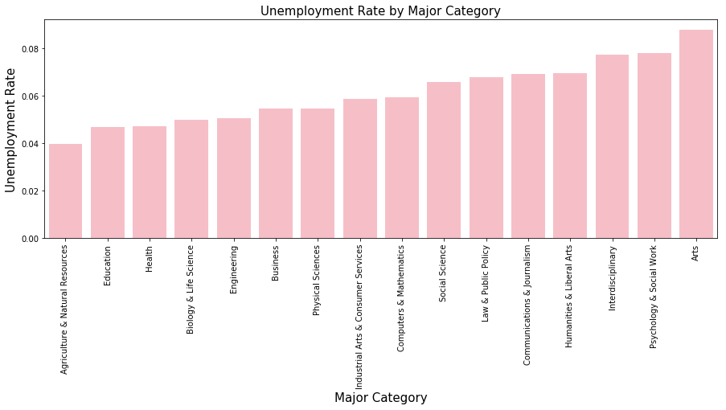

```python
plt.figure(figsize=(15,5))
locs, labels = plt.xticks()
plt.title('Unemployment Rate by Major Category', fontsize=15)
plt.setp(labels, rotation=90)
ax = sns.barplot(x=all_ages_sorted_df['Major_category'],y=all_ages_sorted_df['Unemployment_rate'],color='lightpink', ci=None)
ax.set_xlabel('Major Category', fontsize=15)
ax.set_ylabel('Unemployment Rate', fontsize=15)
plt.savefig('Unemployment-by-Major.png', bbox_inches = "tight")
```

Looks pretty good! It appears that the Agriculture & Natural Resources category has the lowest unemployment rate (around 0.04) and the Arts category has the highest unemployment rate (just above 0.08).

[figure not shown]

Just like above, we will want to read the data into a Pandas dataframe and check its dimensions.

```python
recent_grads_df = pd.read_csv('recent-grads.csv')
```

```python
recent_grads_df.shape
```

```
(173, 21)
```

We will also want to check whether there are any missing values, like we did above. In this case, it appears that we have missing values for the "Food Science" major. However, let's not touch this row yet. We need some of the information it contains as-is, and we can address the null values in a more targeted later after reshaping the dataframe.

```python
recent_grads_df[pd.isnull(recent_grads_df).any(axis=1)]
```

|  | Rank | Major_code | Major | Total | Men | Women | Major_category | ShareWomen | Sample_size | Employed | ... | Part_time | Full_time_year_round | Unemployed | Unemployment_rate | Median | P25th | P75th | College_jobs | Non_college_jobs | Low_wage_jobs |
| --- | --- | --- | --- | --- | --- | --- | --- | --- | --- | --- | --- | --- | --- | --- | --- | --- | --- | --- | --- | --- | --- |
| 21 | 22 | 1104 | FOOD SCIENCE | NaN | NaN | NaN | Agriculture & Natural Resources | NaN | 36 | 3149 | ... | 1121 | 1735 | 338 | 0.096931 | 53000 | 32000 | 70000 | 1183 | 1274 | 485 |

1 rows × 21 columns

```python
recent_grads_df.head()
```

|  | Rank | Major_code | Major | Total | Men | Women | Major_category | ShareWomen | Sample_size | Employed | ... | Part_time | Full_time_year_round | Unemployed | Unemployment_rate | Median | P25th | P75th | College_jobs | Non_college_jobs | Low_wage_jobs |
| --- | --- | --- | --- | --- | --- | --- | --- | --- | --- | --- | --- | --- | --- | --- | --- | --- | --- | --- | --- | --- | --- |
| 0 | 1 | 2419 | PETROLEUM ENGINEERING | 2339.0 | 2057.0 | 282.0 | Engineering | 0.120564 | 36 | 1976 | ... | 270 | 1207 | 37 | 0.018381 | 110000 | 95000 | 125000 | 1534 | 364 | 193 |
| 1 | 2 | 2416 | MINING AND MINERAL ENGINEERING | 756.0 | 679.0 | 77.0 | Engineering | 0.101852 | 7 | 640 | ... | 170 | 388 | 85 | 0.117241 | 75000 | 55000 | 90000 | 350 | 257 | 50 |
| 2 | 3 | 2415 | METALLURGICAL ENGINEERING | 856.0 | 725.0 | 131.0 | Engineering | 0.153037 | 3 | 648 | ... | 133 | 340 | 16 | 0.024096 | 73000 | 50000 | 105000 | 456 | 176 | 0 |
| 3 | 4 | 2417 | NAVAL ARCHITECTURE AND MARINE ENGINEERING | 1258.0 | 1123.0 | 135.0 | Engineering | 0.107313 | 16 | 758 | ... | 150 | 692 | 40 | 0.050125 | 70000 | 43000 | 80000 | 529 | 102 | 0 |
| 4 | 5 | 2405 | CHEMICAL ENGINEERING | 32260.0 | 21239.0 | 11021.0 | Engineering | 0.341631 | 289 | 25694 | ... | 5180 | 16697 | 1672 | 0.061098 | 65000 | 50000 | 75000 | 18314 | 4440 | 972 |

5 rows × 21 columns

```python
# Merging all-ages and recent-grads datasets.
merged_grads_df = pd.merge(all_ages_df, recent_grads_df[['Unemployment_rate', 'Total', 'Employed', 'Unemployed']], how='inner',
                           on=recent_grads_df['Major_code'], suffixes=('_all', '_recent')).dropna()
```

```python
merged_grads_df.head()
```

|  | key_0 | Major_code | Major | Major_category | Total_all | Employed_all | Employed_full_time_year_round | Unemployed_all | Unemployment_rate_all | Median | P25th | P75th | Unemployment_rate_recent | Total_recent | Employed_recent | Unemployed_recent |
| --- | --- | --- | --- | --- | --- | --- | --- | --- | --- | --- | --- | --- | --- | --- | --- | --- |
| 0 | 2419 | 1100 | GENERAL AGRICULTURE | Agriculture & Natural Resources | 128148 | 90245 | 74078 | 2423 | 0.026147 | 50000 | 34000 | 80000.0 | 0.018381 | 2339.0 | 1976 | 37 |
| 1 | 2416 | 1101 | AGRICULTURE PRODUCTION AND MANAGEMENT | Agriculture & Natural Resources | 95326 | 76865 | 64240 | 2266 | 0.028636 | 54000 | 36000 | 80000.0 | 0.117241 | 756.0 | 640 | 85 |
| 2 | 2415 | 1102 | AGRICULTURAL ECONOMICS | Agriculture & Natural Resources | 33955 | 26321 | 22810 | 821 | 0.030248 | 63000 | 40000 | 98000.0 | 0.024096 | 856.0 | 648 | 16 |
| 3 | 2417 | 1103 | ANIMAL SCIENCES | Agriculture & Natural Resources | 103549 | 81177 | 64937 | 3619 | 0.042679 | 46000 | 30000 | 72000.0 | 0.050125 | 1258.0 | 758 | 40 |
| 4 | 2405 | 1104 | FOOD SCIENCE | Agriculture & Natural Resources | 24280 | 17281 | 12722 | 894 | 0.049188 | 62000 | 38500 | 90000.0 | 0.061098 | 32260.0 | 25694 | 1672 |

Now we're faced with the question of how we want to think about recent trends in major popularity. One way to quantify these trends is to look at major category popularity as a function of the proportion of total graduates who enrolled in that category. If a higher proportion enroll in a given category the following year compared to the previous year, then we could say that the major category has increased in popularity.

We have information about all gradautes and about recent graduates. After checking the data documentation, I started out by making the assumption that in order to access information about nonrecent graduates, we could need to subtract values related to recent graduates from the overall data. That would theoretically prevent us from measuring the recent graduates twice.

```python
# Creating a new column that represents only nonrecent grads (so recent grads aren't measured twice)
merged_grads_df['Total_nonrecent'] = merged_grads_df['Total_all']-merged_grads_df['Total_recent']
```

```python
# Creating a column representing the total number of nonrecent grads
merged_grads_df['Total_nonrecent_sum'] = sum(merged_grads_df['Total_nonrecent'])
```

```python
# Calculating the proportion of nonrecent grads in each major
merged_grads_df['Total_nonrecent_pct'] = (merged_grads_df['Total_nonrecent']/merged_grads_df['Total_nonrecent_sum'])
```

```python
merged_grads_df[['Total_all', 'Total_recent']].head()
```

|  | Total_all | Total_recent |
| --- | --- | --- |
| 0 | 128148 | 2339.0 |
| 1 | 95326 | 756.0 |
| 2 | 33955 | 856.0 |
| 3 | 103549 | 1258.0 |
| 4 | 24280 | 32260.0 |

What we can do instead is simply compare recent graduates to the all-ages data directly. The method won't be as clean as the one outlined above, but it will give us enough information to infer some insights about trends in major choice.

```python
# Creating a column representing the sum of all grads
merged_grads_df['Total_all_sum'] = sum(merged_grads_df['Total_all'])
```

```python
# Creating a column representing the proportion of all grads in each major
merged_grads_df['Total_all_pct'] = merged_grads_df['Total_all']/merged_grads_df['Total_all_sum']
```

```python
# Creating a column representing the sum of recent grads
merged_grads_df['Total_recent_sum'] = sum(merged_grads_df['Total_recent'])
```

```python
# Calculating the proportion of recent grads in each major
merged_grads_df['Total_recent_pct'] = (merged_grads_df['Total_recent']/merged_grads_df['Total_recent_sum'])
```

```python
# Calculating the change in proportion per major between nonrecent and recent grads
merged_grads_df['Total_delta'] = merged_grads_df['Total_recent_pct'] - merged_grads_df['Total_all_pct']
```

```python
# Grouping the dataframe by major category
grouped_grads_df = merged_grads_df.groupby('Major_category').mean().reset_index()
```

```python
# Sorting the dataframe by unemployment rate for all grads
grouped_grads_sorted_df = grouped_grads_df.sort_values(by='Unemployment_rate_all')
```

```python
grouped_grads_sorted_df.head()
```

|  | Major_category | key_0 | Major_code | Total_all | Employed_all | Employed_full_time_year_round | Unemployed_all | Unemployment_rate_all | Median | P25th | ... | Employed_recent | Unemployed_recent | Total_nonrecent | Total_nonrecent_sum | Total_nonrecent_pct | Total_all_sum | Total_all_pct | Total_recent_sum | Total_recent_pct | Total_delta |
| --- | --- | --- | --- | --- | --- | --- | --- | --- | --- | --- | --- | --- | --- | --- | --- | --- | --- | --- | --- | --- | --- |
| 0 | Agriculture & Natural Resources | 3050.800000 | 1152.500000 | 63243.700000 | 48041.500000 | 38918.800000 | 1855.100000 | 0.039569 | 55000.000000 | 36550.000000 | ... | 13044.500000 | 876.100000 | 46375.700000 | 32984939.0 | 0.001406 | 39756593.0 | 0.001591 | 6771654.0 | 0.002491 | 0.000900 |
| 6 | Education | 4585.187500 | 2387.687500 | 293757.375000 | 177074.937500 | 116694.500000 | 7833.500000 | 0.046762 | 43831.250000 | 33221.875000 | ... | 44834.937500 | 3084.062500 | 240094.375000 | 32984939.0 | 0.007279 | 39756593.0 | 0.007389 | 6771654.0 | 0.007925 | 0.000536 |
| 8 | Health | 4003.416667 | 5937.916667 | 245904.916667 | 182724.333333 | 127926.083333 | 6251.083333 | 0.047209 | 56458.333333 | 40066.666667 | ... | 26482.750000 | 1979.000000 | 213757.000000 | 32984939.0 | 0.006480 | 39756593.0 | 0.006185 | 6771654.0 | 0.004747 | -0.001438 |
| 2 | Biology & Life Science | 4026.071429 | 3475.857143 | 95584.714286 | 67647.000000 | 48751.714286 | 4095.357143 | 0.049936 | 50821.428571 | 33214.285714 | ... | 26525.500000 | 2426.428571 | 60952.642857 | 32984939.0 | 0.001848 | 39756593.0 | 0.002404 | 6771654.0 | 0.005114 | 0.002710 |
| 7 | Engineering | 3744.379310 | 2489.896552 | 123310.793103 | 90412.620690 | 76414.206897 | 5047.896552 | 0.050630 | 77758.620690 | 52458.620690 | ... | 23634.862069 | 1804.689655 | 93713.931034 | 32984939.0 | 0.002841 | 39756593.0 | 0.003102 | 6771654.0 | 0.004371 | 0.001269 |

5 rows × 23 columns

```python
reshaped_grads_total_df = pd.melt(grouped_grads_sorted_df, id_vars=['Major_category'],
                            value_vars=['Total_all_pct', 'Total_recent_pct'])
```

```python
reshaped_grads_total_df.head()
```

|  | Major_category | variable | value |
| --- | --- | --- | --- |
| 0 | Agriculture & Natural Resources | Total_all_pct | 0.001591 |
| 1 | Education | Total_all_pct | 0.007389 |
| 2 | Health | Total_all_pct | 0.006185 |
| 3 | Biology & Life Science | Total_all_pct | 0.002404 |
| 4 | Engineering | Total_all_pct | 0.003102 |

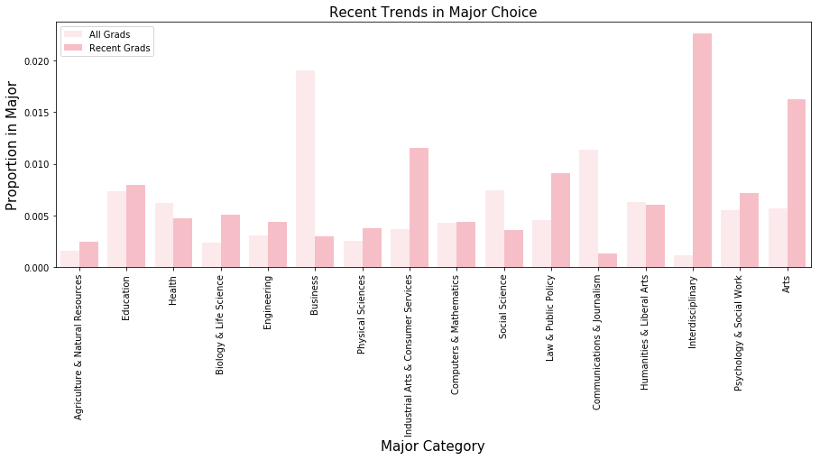

```python
plt.figure(figsize=(15,5))
locs, labels = plt.xticks()
plt.title('Recent Trends in Major Choice', fontsize=15)
plt.setp(labels, rotation=90)
ax = sns.barplot(x=reshaped_grads_total_df['Major_category'],y=reshaped_grads_total_df['value'],color='lightpink',
                 hue=reshaped_grads_total_df['variable'], ci=None)
ax.set_xlabel('Major Category', fontsize=15)
ax.set_ylabel('Proportion in Major', fontsize=15)
ax.legend(['All Grads', 'Recent Grads'], loc = "upper left")
plt.savefig('Trends-in-Major-Choice.png', bbox_inches = "tight")
```

Our first plot shows the side-by-side proportions of all ages vs. recent graduates in each major category. At a glance we can see that recent grads have more interest in majors such as "Industrial Arts & Consuer Services," "Law & Public Policy," "Arts," and interdisciplinary majors. There is lesss interest in majors categories including "Business" and "Communications & Journalism."

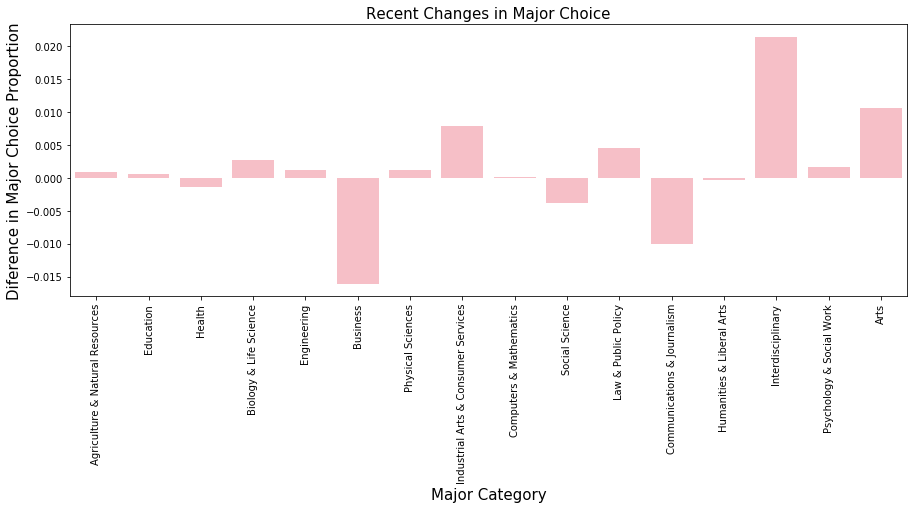

```python
plt.figure(figsize=(15,5))
locs, labels = plt.xticks()
plt.title('Recent Changes in Major Choice', fontsize=15)
plt.setp(labels, rotation=90)
ax = sns.barplot(x=grouped_grads_sorted_df['Major_category'],y=grouped_grads_sorted_df['Total_delta'],
                 color='lightpink', ci=None)
ax.set_xlabel('Major Category', fontsize=15)
ax.set_ylabel('Diference in Major Choice Proportion', fontsize=15)
# ax.legend(['All Grads', 'Recent Grads'], loc = "upper left", title = "Age Range")
plt.savefig('Change-in-Major-Choice.png', bbox_inches = "tight")
```

We can make the visualization even simpler to interpret by just plotting the difference between major choice for all graduates vs. recent graduates. This makes it quicker for the viewer to tell which major categories had a large drop in interest (Business, Communications & Journalism) and which had an increase in interest (Industrial Arts & Comsumer Services, Law & Public Policy, Arts, and Interdisciplinary).

[figure not shown]

Just for fun, since we have the data available in the recent graduates dataset, let's look at income as it relates to the proportion of women per major category. We also have a sub-dataset specifically containing information about women in STEM majors. It could be interesting to compare our information about women in STEM to information about women in all majors.

First, let's check the average proportion of women in all majors, as well as in just STEM majors.

```python
women_stem_df = pd.read_csv('women-stem.csv')
```

```python
# Proportion of women in all majors
recent_grads_df['ShareWomen'].mean()
```

```
0.5222233649593027
```

```python
# Proportion of women in STEM majors
women_stem_df['ShareWomen'].mean()
```

```
0.43692924057894733
```

From the numbers above, we can see that women make up approximately half (52%) of graduates from all majors. However, they only make up 43% of STEM majors.

Next, for a broad idea of what we're working with, we can create a correlation matrix using variables related to gender, employment, and income. We can visualize our matrix using the heatmap shown below.

```python
corr = recent_grads_df[['Men', 'Women', 'ShareWomen', 'Unemployment_rate', 'Median']].corr(method='pearson', min_periods=1)
```

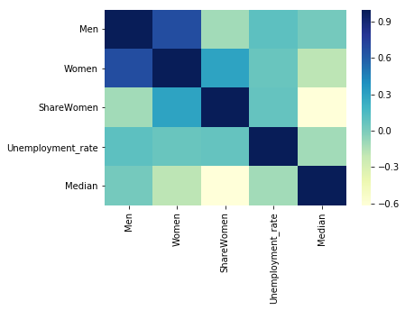

```python
sns.heatmap(corr, cmap="YlGnBu")
plt.savefig('Corr-Mtx.png', bbox_inches = "tight")
```

Looking at this heatmap for all majors, we can already see that the proportion of women in a major category ("ShareWomen") is inversely correlated with income ("Median"). In other words, a higher proportion of women in a major is related to a lower median income among graduates who were in that major. Specifically, the correlation coefficient is -0.62.

```python
# Correlation between the proportion of women in all majors and median income
recent_grads_df['Median'].corr(recent_grads_df['ShareWomen'])
```

```
-0.6186897512131608
```

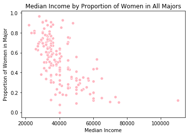

```python
plt.title('Median Income by Proportion of Women in All Majors')
ax = sns.scatterplot(x=recent_grads_df['Median'], y=recent_grads_df['ShareWomen'], color='lightpink')
ax.set_xlabel('Median Income')
ax.set_ylabel('Proportion of Women in Major')
plt.savefig('Women-All-Majors-Income.png', bbox_inches = "tight")
```

The scatterplot above provides a more detailed view of the correlation between proportion of women in each major and median income.

Focusing more specifically at women in STEM majors, there is still an inverse correlation between proportion of women in a major and median income. However, the correlation coefficient is slightly smaller, at -0.58.

```python
# Correlation between proportion of women in STEM majors and median income for STEM graduates
women_stem_df['Median'].corr(women_stem_df['ShareWomen'])
```

```
-0.5825887161066747
```

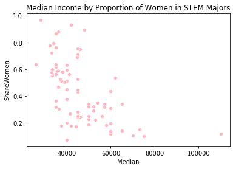

```python
plt.title('Median Income by Proportion of Women in STEM Majors')
sns.scatterplot(x=women_stem_df['Median'], y=women_stem_df['ShareWomen'], color='lightpink')
ax.set_xlabel('Median Income')
ax.set_ylabel('Proportion of Women in Major')
plt.savefig('Women-STEM-Majors-Income.png', bbox_inches = "tight")
```

Like the previous scatterplot, this plot once again shows in more detail that the proportion of women in STEM majors is inversely correlated with median income.

```python
# Median income of all grads
recent_grads_df['Median'].median()
```

```
36000.0
```

```python
# Median income of STEM grads (including men and women, despite the dataset name)
women_stem_df['Median'].median()
```

```
44350.0
```

```python
# Difference between median income of STEM grads and all grads
women_stem_df['Median'].median()-recent_grads_df['Median'].median()
```

```
8350.0
```

Taken together, these analyses suggest that there is room for improvement in connecting women with higher-paid jobs. Although over half of graduates from all majors are women, majors that have high proportions of women tend to be associated with lower incomes. For example STEM majors have a median income of \$44350, which is over \$8000 above the median income for all majors. However, the proportion of women drops from over half in all majors to about 43% in STEM majors. Furthermore, not all STEM majors lead to high incomes, and we tend to see that women are more prevalent among the lower-paid STEM majors.

So, is there anything hopeful we can infer from our data? Let's look at one more aspect of the data: Unemployment rates among women. Going back to our heat map for all majors, unemployment rate doesn't seem to be correlated with the proportion of women in a major. Let's look more closely at that correlation for all majors, as well as specifically for STEM majors.

```python
# Correlation between unemployment rate and proportion of women in all majors
recent_grads_df['Unemployment_rate'].corr(recent_grads_df['ShareWomen'])
```

```
0.07320457867229316
```

```python
# Get employment info for women in stem because it's not present in the original dataset
women_stem_employment_df = recent_grads_df[recent_grads_df['Major_category'].isin(women_stem_df['Major_category'].unique())]
```

```python
# Correlation between unemployment rate and proportion of women in STEM majors
women_stem_employment_df['Unemployment_rate'].corr(women_stem_employment_df['ShareWomen'])
```

```
-0.003478222726572039
```

Looking at the correlations between unemployment rates and the proportion of women in majors, it does not appear that the proportion of women in all majors - or specifically in STEM majors - correlated with employment rate, with correlation coefficients of 0.073 and -0.003 respectively. It appears that the proportion of women in a major is not associated with employment rates, even among STEM majors. While we don't have enough information to draw a definite conclusion about employment rates among women, this insight could be a positive indicator that there is demand for women in higher-paid jobs.